# Milestone Project

Jeevithiesh Duggani

27/05/2020

## Abstract

The aim of the **Capstone Project** is to create a **Shiny App** to predict the next word in a sentence. The goal of this report is to

1. Initialization
2. Download and extract the datasets
3. Import the datasets
4. Perform Exploratory Data Analysis
5. Clean the datasets
6. Create and store unigrams, bigrams and trigrams.
7. Explain the steps to be taken when building the app.

## Initialization

Import the following libraries

- stringi
- tm
- RWeka
- SnowballC
- ggplot2

```r
    library(stringi)
    library(tm)
    library(RWeka)
    library(SnowballC)
    library(ggplot2)
```

## Dataset Download and Extraction

The dataset used in this project is [Coursera-Swiftkey Dataset](https://d396qusza40orc.cloudfront.net/dsscapstone/dataset/Coursera-SwiftKey.zip).

If *Coursera-SwiftKey.zip* and *final* are not present in the current working directory, download and extract the datasets.

```r
    url     <- "http://d396qusza40orc.cloudfront.net/dsscapstone/dataset/Coursera-SwiftKey.zip"
    zipFile <- "Coursera-SwiftKey.zip"
    dFolder <- "final"
    if(!(file.exists(zipFile) | file.exists(dFolder))) download.file(url, zipFile)
    if(!file.exists(dFolder)) unzip(zipFile)
    if(file.exists(zipFile)) file.remove(zipFile)
```

## Import Datasets

This project deals with the english words. Hence import *en_US.blogs.txt*, *en_US.news.txt* and *en_US.twitter.txt* into `blogData`, `newsData` and `twitterData`.

```r
    folder      <- "./final/en_US/"
    blogData    <- readLines(paste0(folder, "en_US.blogs.txt"),   encoding = "UTF-8", skipNul = TRUE)
    newsData    <- readLines(paste0(folder, "en_US.news.txt"),    encoding = "UTF-8", skipNul = TRUE)
    twitterData <- readLines(paste0(folder, "en_US.twitter.txt"), encoding = "UTF-8", skipNul = TRUE)
```

### Exploratory Data Analysis

Find the number of words and lines in each dataset.

```r
    Exploration <- data.frame(Dataset    = c("blogData",
                                             "newsData",
                                             "twitterData"),
                              Lines      = c(length(blogData),
                                             length(newsData),
                                             length(twitterData)),
                              Words      = c(sum(stri_count_words(blogData)),
                                             sum(stri_count_words(newsData)),
                                             sum(stri_count_words(twitterData)))
                            )
    Exploration
```

```
##       Dataset   Lines    Words
## 1    blogData  899288 37546239
## 2    newsData   77259  2674536
## 3 twitterData 2360148 30093413
```

## Cleaning the Datasets

```r
    set.seed(2020)
    trainData <- c(sample(blogData, 8892), sample(newsData, 772), sample(twitterData, 23601))
```

```r
    Textprocessing <- function(x){
        gsub("http[[:alnum:]]*",'', x)
        gsub('http\\S+\\s*', '', x) ## Remove URLs
        gsub('\\b+RT', '', x) ## Remove RT
        gsub('#\\S+', '', x) ## Remove Hashtags
        gsub('@\\S+', '', x) ## Remove Mentions
        gsub('[[:cntrl:]]', '', x) ## Remove Controls and special characters
        gsub("\\d", '', x) ## Remove Controls and special characters
        gsub('[[:punct:]]', '', x) ## Remove Punctuations
        gsub('-', '', x) ## remove hypens
        gsub("^[[:space:]]*","",x) ## Remove leading whitespaces
        gsub("[[:space:]]*$","",x) ## Remove trailing whitespaces
        gsub(' +',' ',x) ## Remove extra whitespaces
    }
```

The Cleaning of the Data is done in the following steps.

- Convert the `trainData` into a corpus.
- Change the case of all the words to lower.
- Remove all non-words (numbers, special characters, punctuations, additional whitespaces)
- Remove stop words from the corpus
- Convert the corpus to a plain text document

```r
    corpus <- Corpus(VectorSource(trainData))

    corpus <- tm_map(corpus, PlainTextDocument)
    corpus <- tm_map(corpus, tolower)
    corpus <- tm_map(corpus, removeNumbers)
    corpus <- tm_map(corpus, removePunctuation)
    corpus <- tm_map(corpus, Textprocessing)
    corpus <- tm_map(corpus, removeWords, stopwords("en"))
    corpus <- tm_map(corpus, stripWhitespace)

    corpus <- VCorpus(VectorSource(corpus), readerControl=list(reader=readPlain, language="en"))
    saveRDS( corpus, 'Corpus.RDS')
```

## NGram Creation

Inorder to generate predicition we need to train the model on unigrams, bigrams and trigrams.

### Unigram

```r
    uniCorpus <- TermDocumentMatrix(corpus)
    uniCorpus <- removeSparseTerms(uniCorpus, 0.999)
    unifreq   <- sort(rowSums(as.matrix(uniCorpus)), decreasing = T)
    unigram   <- data.frame(token = names(unifreq), freq = unifreq)
    saveRDS(unigram, 'Unigram.RDS')
```

Plot the top 20 unigrams with respect to their frequencies

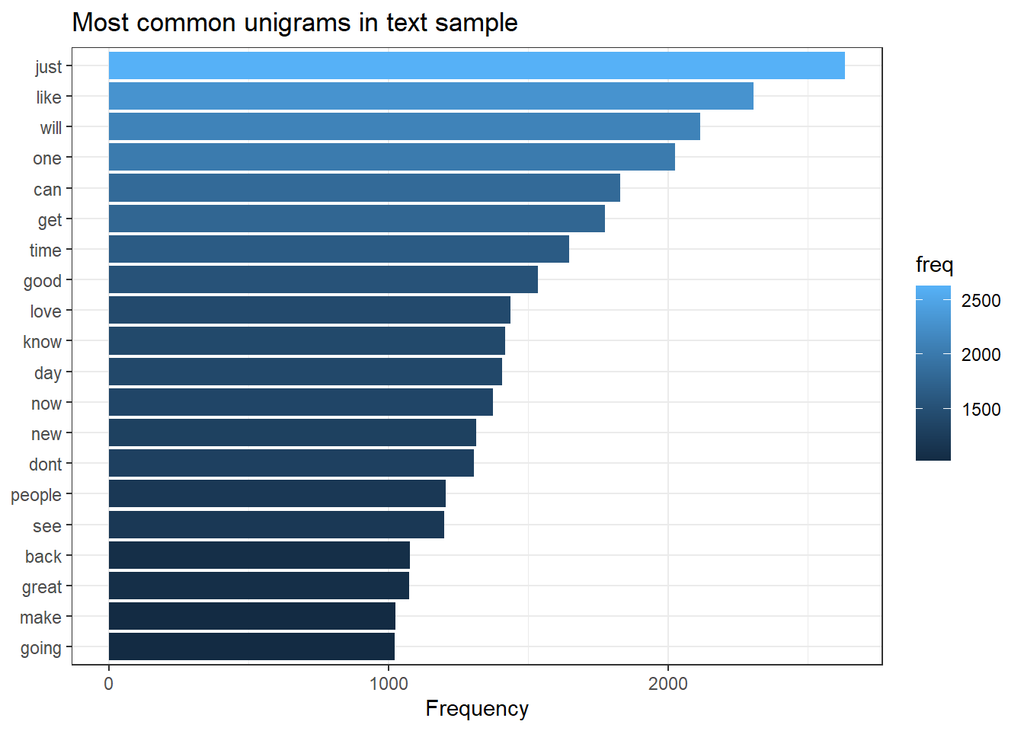

```r
    plotData  <- head(unigram, 20)

    plot <- ggplot(plotData, aes(x = reorder(token, freq), y = freq, fill = freq))
    plot <- plot + geom_bar(stat="identity")
    plot <- plot + theme_bw() + coord_flip() + theme(axis.title.y = element_blank())
    plot <- plot + labs(y="Frequency", title="Most common unigrams in text sample")
    plot
```

### Bigrams

```r
    biCorpus <- TermDocumentMatrix(corpus,
                                    control=list(tokenize = function (x) NGramTokenizer(x,
                                                                                        Weka_control(min = 2,
                                                                                                     max = 2))))
    biCorpus <- removeSparseTerms(biCorpus, 0.9999)
    bifreq   <- sort(rowSums(as.matrix(biCorpus)), decreasing = T)
    bigram   <- data.frame(token = names(bifreq), freq = bifreq)
    saveRDS(bigram, 'Bigram.RDS')
```

Plot the top 20 bigrams with respect to their frequencies

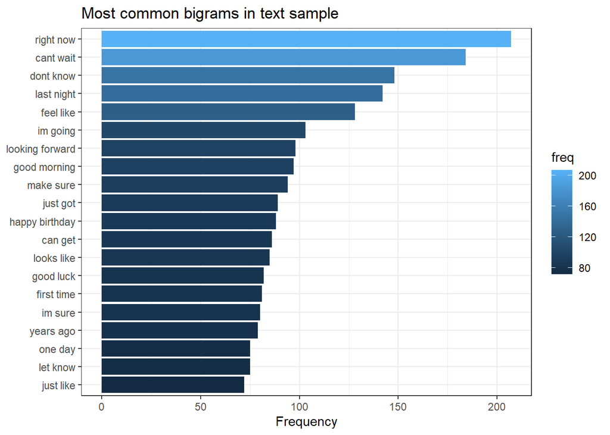

```r
    plotData  <- head(bigram, 20)

    plot <- ggplot(plotData, aes(x = reorder(token, freq), y = freq, fill = freq))
    plot <- plot + geom_bar(stat="identity")
    plot <- plot + theme_bw() + coord_flip() + theme(axis.title.y = element_blank())
    plot <- plot + labs(y="Frequency", title="Most common bigrams in text sample")
    plot
```

### Trigram

```r
    triCorpus <- TermDocumentMatrix(corpus,
                                    control=list(tokenize = function (x) NGramTokenizer(x,
                                                                                        Weka_control(min = 3,
                                                                                                     max = 3))))
    triCorpus <- removeSparseTerms(triCorpus, 0.99995)
    trifreq   <- sort(rowSums(as.matrix(triCorpus)), decreasing = T)
    trigram   <- data.frame(token = names(trifreq), freq = trifreq)
    saveRDS(trigram, 'trigram.RDS')
```

Plot the top 20 trigrams with respect to their frequencies

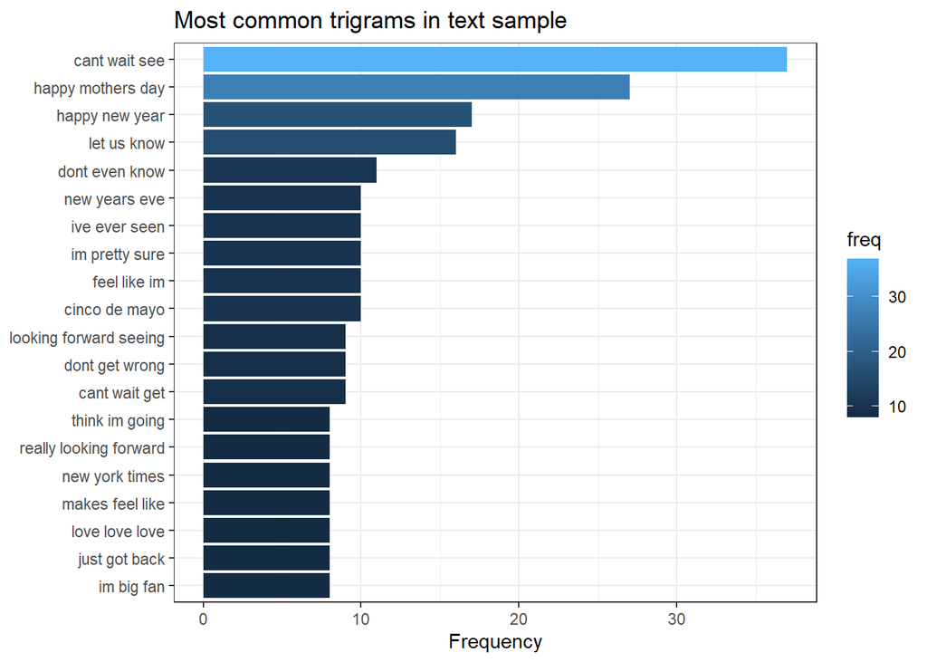

```r
    plotData  <- head(trigram, 20)

    plot <- ggplot(plotData, aes(x = reorder(token, freq), y = freq, fill = freq))
    plot <- plot + geom_bar(stat="identity")
    plot <- plot + theme_bw() + coord_flip() + theme(axis.title.y = element_blank())
    plot <- plot + labs(y="Frequency", title="Most common trigrams in text sample")
    plot
```

## Next Steps

The next step is to create a model and integrate it into a Shiny app for word prediction.

### Model

1. Use the Ngram dataframes created to calculate the probabilities of the next word.
2. Tokenize the input string
3. Cross Check the quadgrams, trigrams, bigrams and unigrams in the end of the input string with the Ngram dataframes in order to identify the next word.

### Shiny App

1. Integrate the model framework created above into a shiny application.
2. Generate the Shiny App.
3. Create a presentation for the Shiny App.
4. Publish the presentation and the app.